# Social Care Survey Open Data

# Introduction

The majority of variables are factors so we probabaly won’t get the full benefit of `skimr` but am keen to try it out.

## Load data

Load in tidied data

```r
load("produced_data/created_objects/soc_care10.rds")
load("produced_data/created_objects/soc_care11.rds")
load("produced_data/created_objects/soc_care12.rds")
```

## Load packages

And required packages

```r
library(dplyr)
library(ggplot2)
library(ggthemes)
library(readr)
library(purrr)
library(stringr)
library(tidyr)
library(magrittr)
library(forcats)
library(extrafont)
theme_set(theme_tufte(base_size = 18))
ubdc_palette <- c("#13AFD6", "#E6E600", "#F07329", "#35B14E", "#D7509A", "#2165AF",
                  "#BCD032","#866BAC", "#545A5D",  "#7A8082", "#E2D988", "#628DB7",
                  "#929B9A", "#93B8DA", "#31649B", "#FBF8D0", "#ACB2B4", "#D1DAE2")
```

# Examine data

## Summaries

```r
soc_care10
```

| council | client_id | age_grp | client_grp | gender | la_hrs | pri_hrs | vol_hrs | total_hrs | hc_client | living_arr | multi_staff | housing_type | laundry | shopping | housing_supp |
| --- | --- | --- | --- | --- | --- | --- | --- | --- | --- | --- | --- | --- | --- | --- | --- |
| Aberdeen City | ZZXJX | NA | NA | NA | Zero | Zero | Zero | Zero | No | NA | Single Staff | Mainstream | No | No | No |
| Aberdeen City | VLKT8 | 85+ | Infirmity due to Age | Male | Zero | 2-4 | Zero | 2-4 | Yes | NA | Single Staff | Mainstream | No | No | No |
| Aberdeen City | 418H1 | 75-<85 | Infirmity due to Age | Male | Zero | 6-8 | Zero | 6-8 | Yes | Other | Single Staff | Mainstream | No | No | No |
| Aberdeen City | 7SF1N | 85+ | Infirmity due to Age | Male | Zero | 6-8 | Zero | 6-8 | Yes | Lives Alone | Single Staff | Mainstream | No | No | No |
| Aberdeen City | TKCFN | 75-<85 | Infirmity due to Age | Male | Zero | 15-20 | Zero | 15-20 | Yes | Lives Alone | Single Staff | Mainstream | No | No | No |
| Aberdeen City | 5EFK3 | 75-<85 | Infirmity due to Age | Female | Zero | 15-20 | Zero | 15-20 | Yes | Lives Alone | Single Staff | Mainstream | No | No | No |
| Aberdeen City | DAK8A | 75-<85 | Infirmity due to Age | Male | Zero | 2-4 | Zero | 2-4 | Yes | NA | Single Staff | Mainstream | No | No | No |
| Aberdeen City | V7E3J | 75-<85 | Infirmity due to Age | Male | Zero | 4-6 | Zero | 4-6 | Yes | NA | Single Staff | Mainstream | No | No | No |
| Aberdeen City | 17D8B | 75-<85 | Infirmity due to Age | Male | 6-8 | Zero | Zero | 6-8 | Yes | Other | Single Staff | Mainstream | No | No | No |
| Aberdeen City | Z3BO7 | NA | NA | NA | Zero | Zero | Zero | Zero | No | NA | Single Staff | Mainstream | No | No | No |

[output cut: 990 more lines]

```r
soc_care11
```

| council | client_id | age_grp | client_grp | gender | la_hrs | pri_hrs | vol_hrs | pc_hrs | total_hrs | hc_client | comm_alarm | other_telecare | alarm_and_tele | living_arr | multi_staff | housing_type | laundry | shopping | housing_supp |
| --- | --- | --- | --- | --- | --- | --- | --- | --- | --- | --- | --- | --- | --- | --- | --- | --- | --- | --- | --- |
| Aberdeen City | 17L9J | 75-<85 | Infirmity due to Age | Female | Zero | Zero | Zero | Zero | Zero | No | No | Yes | No | NA | Single Staff | Mainstream | No | No | No |
| Aberdeen City | 3Z8FK | 85+ | Infirmity due to Age | Female | Zero | Zero | Zero | Zero | Zero | No | Yes | No | No | Other | Single Staff | Mainstream | No | No | No |
| Aberdeen City | BKKAY | 75-<85 | Dementia & Mental Health | Female | Zero | Zero | Zero | Zero | Zero | No | Yes | No | No | NA | Single Staff | Mainstream | No | No | No |
| Aberdeen City | 8BT1I | 75-<85 | Dementia & Mental Health | Female | Zero | Zero | Zero | Zero | Zero | No | No | No | No | NA | Single Staff | Mainstream | No | No | No |
| Aberdeen City | XMH3X | 75-<85 | Infirmity due to Age | Male | Zero | 1-2 | Zero | 1-2 | 1-2 | Yes | No | No | No | NA | Single Staff | Mainstream | No | No | No |
| Aberdeen City | YQ6HE | 85+ | Infirmity due to Age | Male | Zero | 6-8 | Zero | 6-8 | 6-8 | Yes | No | No | No | Lives Alone | Single Staff | Mainstream | No | No | No |
| Aberdeen City | 3AAZR | 85+ | Infirmity due to Age | Female | Zero | 4-6 | Zero | 4-6 | 4-6 | Yes | Yes | No | No | Lives Alone | Single Staff | Mainstream | No | No | No |
| Aberdeen City | TTYAU | 75-<85 | Infirmity due to Age | Male | Zero | 15-20 | Zero | 15-20 | 15-20 | Yes | Yes | No | No | Lives Alone | Single Staff | Mainstream | No | No | No |
| Aberdeen City | 1XJ19 | 75-<85 | Infirmity due to Age | Female | 15-20 | Zero | Zero | 15-20 | 15-20 | Yes | No | No | No | NA | 2 or more Staff | Mainstream | No | No | No |
| Aberdeen City | 6C7EW | 85+ | Infirmity due to Age | Female | <1 | Zero | Zero | <1 | <1 | Yes | No | No | No | NA | Single Staff | Mainstream | No | No | No |

[output cut: 990 more lines]

```r
soc_care12
```

| council | client_id | age_grp | client_grp | gender | new_hrs | la_hrs | pri_hrs | vol_hrs | pc_hrs | total_hrs | hc_client | comm_alarm | other_telecare | alarm_and_tele | living_arr | multi_staff | housing_type | laundry | shopping | housing_supp |
| --- | --- | --- | --- | --- | --- | --- | --- | --- | --- | --- | --- | --- | --- | --- | --- | --- | --- | --- | --- | --- |
| Aberdeen City | HRXYJ | 75-<85 | Infirmity due to Age | Female | 0 | Zero | Zero | Zero | Zero | Zero | No | No | Yes | No | NA | Single Staff | Mainstream | No | No | No |
| Aberdeen City | U61VU | 85+ | Infirmity due to Age | Female | 2 | Zero | 2-4 | Zero | 2-4 | 2-4 | Yes | Yes | No | No | Other | Single Staff | Mainstream | No | No | No |
| Aberdeen City | XP2LW | 75-<85 | Dementia & Mental Health | Female | 0 | Zero | Zero | Zero | Zero | Zero | No | No | No | No | NA | Single Staff | Mainstream | No | No | No |
| Aberdeen City | 3VXIH | 75-<85 | Infirmity due to Age | Male | 3 | Zero | 2-4 | Zero | 2-4 | 2-4 | Yes | No | No | No | NA | Single Staff | Mainstream | No | No | No |
| Aberdeen City | 4CC3E | 85+ | Infirmity due to Age | Male | 7 | Zero | 6-8 | Zero | 6-8 | 6-8 | Yes | No | No | No | Lives Alone | Single Staff | Mainstream | No | No | No |
| Aberdeen City | L311I | 75-<85 | Infirmity due to Age | Female | 18 | 15-20 | Zero | Zero | 15-20 | 15-20 | Yes | No | No | No | NA | 2 or more Staff | Mainstream | No | No | No |
| Aberdeen City | OUG1F | 85+ | Infirmity due to Age | Female | 1 | <1 | Zero | Zero | <1 | <1 | Yes | No | No | No | NA | Single Staff | Mainstream | No | No | No |
| Aberdeen City | BU0AY | 65-<75 | Dementia & Mental Health | Female | 0 | Zero | Zero | Zero | Zero | Zero | No | No | Yes | No | Other | Single Staff | Mainstream | No | No | No |
| Aberdeen City | C51LO | 75-<85 | Infirmity due to Age | Male | 0 | Zero | Zero | Zero | Zero | Zero | No | Yes | No | No | NA | Single Staff | Mainstream | No | No | No |
| Aberdeen City | KYLU9 | 85+ | Infirmity due to Age | Female | 3 | Zero | 2-4 | Zero | 2-4 | 2-4 | Yes | Yes | No | No | Lives Alone | Single Staff | Mainstream | No | No | No |

[output cut: 990 more lines]

## Councils

1st thing I want to visualise is the absolute number of records returned for each council and what percentage of the total this is.

I’m going to stick with 2011 data for now. Need to pre-summarise the data…

```r
sc_11_summary <-
  soc_care11 %>%
  group_by(council) %>%
  summarise(any_care = n()) %>%
  mutate(freq = any_care/sum(any_care),
         pct = round(freq * 100,1))
sc_11_summary
```

| council | any_care | freq | pct |
| --- | --- | --- | --- |
| Aberdeen City | 3337 | 0.023423133 | 2.3 |
| Aberdeenshire | 4157 | 0.029178892 | 2.9 |
| Angus | 4571 | 0.032084848 | 3.2 |
| Argyll & Bute | 1904 | 0.013364592 | 1.3 |
| Clackmannanshire | 1541 | 0.010816616 | 1.1 |
| Dumfries & Galloway | 3733 | 0.026202743 | 2.6 |
| Dundee City | 5759 | 0.040423680 | 4.0 |
| East Ayrshire | 4099 | 0.028771777 | 2.9 |
| East Dunbartonshire | 2580 | 0.018109584 | 1.8 |
| East Lothian | 2752 | 0.019316890 | 1.9 |

[output cut: 22 more lines]

…and then plot it

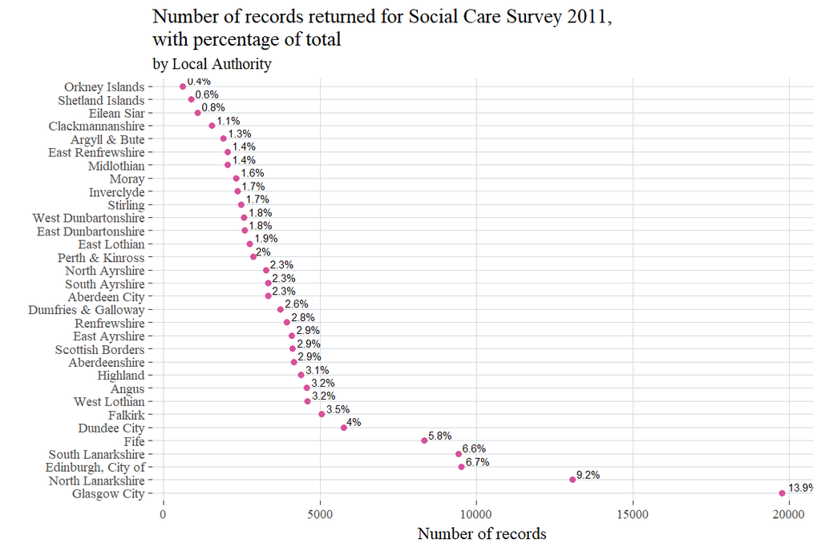

```r
ggplot(sc_11_summary, aes(reorder(council, -any_care), any_care)) +
  geom_point(size = 3, color = ubdc_palette[5]) +
  geom_text(aes(label = paste0(pct,"%"), hjust = -0.2, vjust = -0.2)) +
  coord_flip() +
  theme(panel.grid.major = element_line(ubdc_palette[18])) +
  labs(
    title = "Number of records returned for Social Care Survey 2011,\nwith percentage of total",
    subtitle = "by Local Authority",
    x = "",
    y = "Number of records")
```

# Population comparison

How do these absolute numbers reflect the differing populations in each local authority?

## Create main table

2011 Popoulation estimates downloaded from the National Records of Scotland here:- https://www.nrscotland.gov.uk/statistics-and-data/statistics/statistics-by-theme/population/2011-census-reconciliation-report/list-of-tables

Create `pop_data_combined` a `data_frame` with population sizes of each Local Authority as a total and for over 65s

```r
#Note I cheated and converted data to numeric in excel to remove the commas as 1000 seperators

#import and tidy raw data
pop_data <- read_csv("raw_data/2011-cen-rec-report-pop-tab1b.csv", skip = 3) %>%
  slice(1:34) %>%
  filter(X1 %in% c("Council areas", "SCOTLAND") == FALSE) %>%
  select(-X3, -X23, -X24) %>%
  map_at(2:21, as.numeric) %>% #coerce from character to numeric
  as_data_frame()

names(pop_data) <- str_replace(names(pop_data), "X1", "council") #rename X variables
names(pop_data) <- str_replace(names(pop_data), "X2", "total")

#tidy data for manipulation
pop_data %<>%
  gather(age_grp, value, 2:21) %>%
  arrange(council)


#create table of total population per council
pop_data_total <-
  pop_data %>%
  filter(age_grp == "total") %>%
  select(-age_grp) %>%
  arrange(council)
names(pop_data_total) <- str_replace(names(pop_data_total), "value", "pop_total")

#create table of total over65s per council
pop_data_65plus <-
  pop_data %>%
  filter(age_grp %in% c("65 - 69", "70 - 74", "75 - 79", "80 - 84", "85 - 89",
                        "90+") == TRUE) %>%
  group_by(council) %>%
  mutate(pop_over_65 = sum(value)) %>%
  arrange(council) %>%
  select(council, pop_over_65) %>%
  unique(.)

#join tables together
pop_data_combined <-
  full_join(pop_data_total, pop_data_65plus)

pop_data_combined
```

| council | pop_total | pop_over_65 |
| --- | --- | --- |
| Aberdeen City | 222793 | 32031 |
| Aberdeenshire | 252973 | 40663 |
| Angus | 115978 | 23061 |
| Argyll & Bute | 88166 | 19336 |
| Clackmannanshire | 51442 | 8212 |
| Dumfries & Galloway | 151324 | 33050 |
| Dundee City | 147268 | 24597 |
| East Ayrshire | 122767 | 21307 |
| East Dunbartonshire | 105026 | 20428 |
| East Lothian | 99717 | 17763 |

[output cut: 22 more lines]

```r
rm(list = c("pop_data_65plus", "pop_data_total"))
```

## Add social care

Join to `sc_11_summary` table

```r
pop_data_combined <-
  left_join(pop_data_combined, sc_11_summary) %>%
  select(council, pop_total, pop_over_65, any_care)
pop_data_combined
```

| council | pop_total | pop_over_65 | any_care |
| --- | --- | --- | --- |
| Aberdeen City | 222793 | 32031 | 3337 |
| Aberdeenshire | 252973 | 40663 | 4157 |
| Angus | 115978 | 23061 | 4571 |
| Argyll & Bute | 88166 | 19336 | 1904 |
| Clackmannanshire | 51442 | 8212 | 1541 |
| Dumfries & Galloway | 151324 | 33050 | 3733 |
| Dundee City | 147268 | 24597 | 5759 |
| East Ayrshire | 122767 | 21307 | 4099 |
| East Dunbartonshire | 105026 | 20428 | 2580 |
| East Lothian | 99717 | 17763 | 2752 |

[output cut: 22 more lines]

## Add social care over 65s

Add a column with total amount of records of over 65s from each local authority

```r
#subset over 65s from 2011 data
any_care65s <-
  soc_care11 %>%
  filter(age_grp != "18-<65")

#now count by local authority
care65s <- fct_count(any_care65s$council)
names(care65s) <-
  str_replace(names(care65s), "n", "any_care_over_65s") %>%
  str_replace(., "f", "council")

#and add this to pop_data_combined
pop_data_combined %<>%
  left_join(., care65s)
pop_data_combined
```

| council | pop_total | pop_over_65 | any_care | any_care_over_65s |
| --- | --- | --- | --- | --- |
| Aberdeen City | 222793 | 32031 | 3337 | 2988 |
| Aberdeenshire | 252973 | 40663 | 4157 | 3464 |
| Angus | 115978 | 23061 | 4571 | 3855 |
| Argyll & Bute | 88166 | 19336 | 1904 | 1737 |
| Clackmannanshire | 51442 | 8212 | 1541 | 1250 |
| Dumfries & Galloway | 151324 | 33050 | 3733 | 3146 |
| Dundee City | 147268 | 24597 | 5759 | 4973 |
| East Ayrshire | 122767 | 21307 | 4099 | 3355 |
| East Dunbartonshire | 105026 | 20428 | 2580 | 2196 |
| East Lothian | 99717 | 17763 | 2752 | 2162 |

[output cut: 22 more lines]

```r
rm(care65s)
```

## calculate ratios per 1000 population

```r
#calculate per 1000
pop_data_combined %<>%
  mutate(total_per_thousand = (any_care / pop_total) * 1000) %>%
  mutate(over_65s_per_thousand = (any_care_over_65s / pop_over_65) * 1000)

pop_data_combined
```

| council | pop_total | pop_over_65 | any_care | any_care_over_65s | total_per_thousand | over_65s_per_thousand |
| --- | --- | --- | --- | --- | --- | --- |
| Aberdeen City | 222793 | 32031 | 3337 | 2988 | 14.97803 | 93.28463 |
| Aberdeenshire | 252973 | 40663 | 4157 | 3464 | 16.43258 | 85.18801 |
| Angus | 115978 | 23061 | 4571 | 3855 | 39.41265 | 167.16534 |
| Argyll & Bute | 88166 | 19336 | 1904 | 1737 | 21.59563 | 89.83244 |
| Clackmannanshire | 51442 | 8212 | 1541 | 1250 | 29.95607 | 152.21627 |
| Dumfries & Galloway | 151324 | 33050 | 3733 | 3146 | 24.66892 | 95.18911 |
| Dundee City | 147268 | 24597 | 5759 | 4973 | 39.10558 | 202.17913 |
| East Ayrshire | 122767 | 21307 | 4099 | 3355 | 33.38845 | 157.45999 |
| East Dunbartonshire | 105026 | 20428 | 2580 | 2196 | 24.56535 | 107.49951 |
| East Lothian | 99717 | 17763 | 2752 | 2162 | 27.59810 | 121.71367 |

[output cut: 22 more lines]

## Visualise over 65s

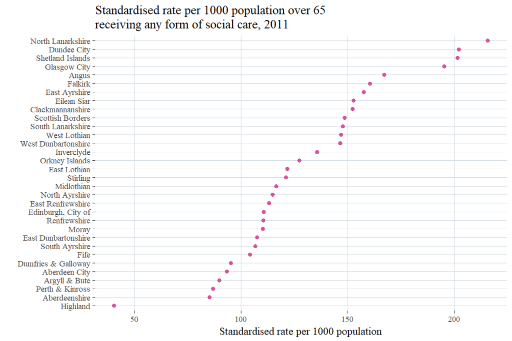

```r
ggplot(pop_data_combined,
       aes(reorder(council, over_65s_per_thousand), over_65s_per_thousand)) +
  geom_point(color = ubdc_palette[5], size = 3) +
  coord_flip() +
  theme(panel.grid.major = element_line(colour = ubdc_palette[18])) +
  labs(
    title = "Standardised rate per 1000 population over 65 \nreceiving any form of social care, 2011",
    x = "",
    y = "Standardised rate per 1000 population"
  )
```

## Highland

```r
highland <-
  soc_care11 %>%
  filter(council == "Highland")

nrow(highland)
```

[1] 4387

```r
fct_count(highland$age_grp)
```

| f | n |
| --- | --- |
| 18-<65 | 304 |
| 65-<75 | 288 |
| 75-<85 | 682 |
| 85+ | 769 |
| NA | 2344 |

Highland is an outlier because 53.4% of its records have missing data for Age group. It is likely most of this missing data will be over 65s.

## Visualise totals

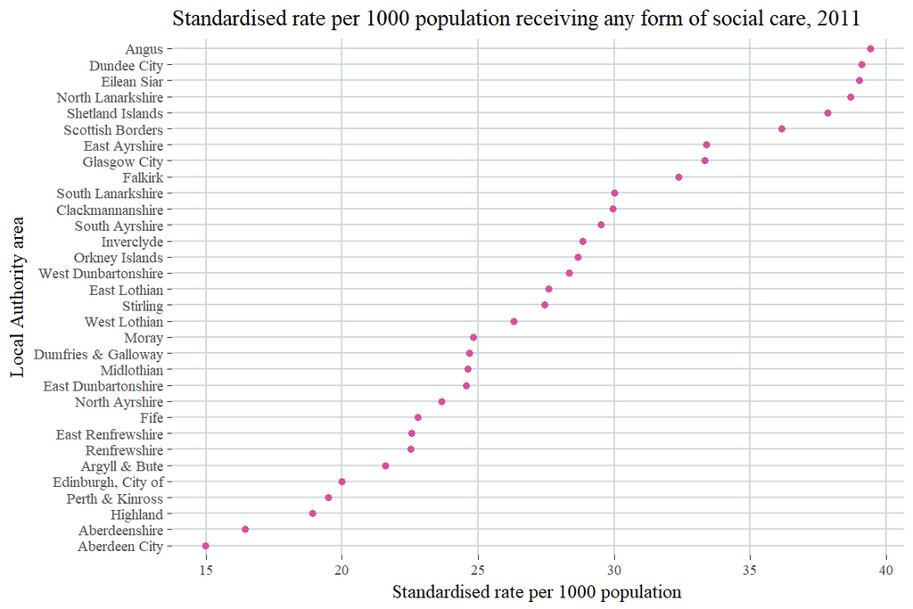

```r
ggplot(pop_data_combined,
       aes(reorder(council, total_per_thousand), total_per_thousand)) +
  geom_point(color = ubdc_palette[5], size = 3) +
  coord_flip() +
  theme(panel.grid.major = element_line(colour = ubdc_palette[18], size = 1)) +
  labs(
    title = "Standardised rate per 1000 population receiving any form of social care, 2011",
    x = "Local Authority area",
    y = "Standardised rate per 1000 population"
  )
```

## save created objects

```r
save(pop_data, file = "produced_data/created_objects/pop_data.rds")
save(pop_data_combined, file = "produced_data/created_objects/pop_data_combined.rds")
save(any_care65s, file = "produced_data/created_objects/any_care65s.rds")
```

# Variable by variable visualisation

## Councils

## Age Group

## Client Group

## Gender

## Meals

## Local Authority Provided Home Care Hours

## Private Company Provided Home Care Hours

## Voluntary Orgnaisation Provided Home Care Hours

## Personal Care Home Care Hours

## Total Home Care Hours

## Home Care Client Flad

## Living Arrangements

## Mutli Staffing

## Housing Type

## Laundry

## Shopping

## Housing Support

## IoRN Score

# Interesting comparison